# Test

OS in Rust

## Announcements

- **Action Items**:
  - How is graphics?
    - Are you learning NumPy?
    - Anyone using CUDA?

## Citations

- I am geniunely convinced of the usefulness of automated testing when developing a system.
- The most high profile case of this is the testing framework for [`4096_t.c`](https://cd-public.github.io/crypto/qmd/bigadd.html)
- Hard to persuade students of the usefulness of this on small class assignments.
- $\therefore$ I’ve never written anything of any reasonable size in Rust, so
- [Testing](https://os.phil-opp.com/testing/)

## Today

- Testing under `no_std`
- QEMU
- `bootimage`
  - Still not in love with this dependency, but we do what we can.

## Pre-work

- Make sure you have a `.cargo/config.toml`
- No idea how you wouldn’t have one of these yet!
- Just make sure you have it.

## Modern Language

- Like Python with Pytest, and unlike the only other systems language, Rust has a testing framework.
- It’s covered in [Rust book](https://doc.rust-lang.org/book/ch11-00-testing.html)
- Naturally I skipped this chapter.

## Framework

- Use the `#[test]` attribute on some functions.
- Including *assertions* within those functions.
- `cargo test` or, if you see someone around, `cargo t`, will check the assertions.
- The crate will otherwise be non-impacted.

## Review

- To enable testing for our kernel binary, we can set the `test` flag in the Cargo.toml to `true`.
- We recall our `Cargo.toml` - mine no longer has an allusions to panic with the introduction of a JSON target.

```
Cargo.toml
```

```
[package]
name = "osirs"
version = "0.1.0"
edition = "2024"

[dependencies]
bootloader = "0.9"
```

## Enable

- This is necessary but not sufficient.

```
Cargo.toml
```

```
[package]
name = "osirs"
version = "0.1.0"
edition = "2024"

[dependencies]
bootloader = "0.9"

[[bin]]
name = "osirs"
test = true
bench = false
```

## On `[[bin]]`

> [The double-bracket sections like `[[bin]]` are array-of-table of TOML, which means you can write more than one `[[bin]]` section to make several executables in your crate.](https://doc.rust-lang.org/cargo/reference/cargo-targets.html#configuring-a-target)
- Just one for us for now.

## Working within `no_std`

- Testing is complicated by `no_std`.
- Rust implicitly uses the `test` library, which depends on `std`
  - [More on `test`](https://doc.rust-lang.org/test/index.html)

```bash
$ cargo t
   Compiling bootloader v0.9.34
error[E0463]: can't find crate for `core`
  |
  = note: the `x86_64-osirs` target may not be installed
  = help: consider downloading the target with `rustup target add x86_64-osirs`

For more information about this error, try `rustc --explain E0463`.
error: could not compile `bootloader` (lib) due to 1 previous error
```

## What We Lose

- Vs. `std`, we lose e.g. `should_panic` tests.
  - [On those](https://doc.rust-lang.org/book/ch11-01-writing-tests.html#checking-for-panics-with-should_panic)
- That’s okay, we are crafty (and wrote our own panic handler anyway).

## To Main

- My main looks like this:

```
src/main.rs
```

```rust
#![no_std]
#![no_main]

mod colors;
mod vga;

#[panic_handler]
fn panic(info: &core::panic::PanicInfo) -> ! {
    println!("{}", info);
    loop {}
}

#[unsafe(no_mangle)]
pub extern "C" fn _start() -> ! {
    colors::colors();
    colors::image();
    loop {}
}
```

## Just a note

- When you make a new version for today (`60`)
  - Probably leave out colors (`52`) and
  - Instead start with something with `println!` (likely `51`)

## Today’s Starting Point

```
src/main.rs
```

```rust
#![no_std]
#![no_main]

mod vga;

#[panic_handler]
fn panic(info: &core::panic::PanicInfo) -> ! {
    println!("{}", info);
    loop {}
}

#[unsafe(no_mangle)]
pub extern "C" fn _start() -> ! {
    println!("Hello world!");
    loop {}
}
```

## Adding to Main

```
src/main.rs
```

```rust
#![no_std]
#![no_main]
#![feature(custom_test_frameworks)]
#![test_runner(crate::test_runner)]

mod vga;

#[cfg(test)]
pub fn test_runner(tests: &[&dyn Fn()]) {
    println!("Running {} tests", tests.len());
    for test in tests {
        test();
    }
}

#[panic_handler]
fn panic(info: &core::panic::PanicInfo) -> ! {
    println!("{}", info);
    loop {}
}

#[unsafe(no_mangle)]
pub extern "C" fn _start() -> ! {
    println!("Hello world!");
    loop {}
}
```

## Wait a minute

- What is `&dyn`?
- [“Keyword `dyn`](https://doc.rust-lang.org/std/keyword.dyn.html)

> The `dyn` keyword is used to highlight that calls to methods on the associated `Trait` are dynamically dispatched.

## Dynamic Dispatch

> [In computer science, **dynamic dispatch** is the process of selecting which implementation of a polymorphic operation (method or function) to call at run time. It is commonly employed in, and considered a prime characteristic of, object-oriented programming (OOP) languages and systems.](https://en.wikipedia.org/wiki/Dynamic_dispatch)

## OOP

- Yeah I’m not doing that.
- We’ll maintain a list of functions.
- If you want to learn about OOP, here is a tutorial on writing a Java app for Android.
  - Create your first Android app
  - Whoops its Kotlin (multi-paradigm).
  - Yet more evidence of the correctness of OOP.

## Write Two Functions

- Doesn’t matter but nice to have externally observable functions.

```
src/main.rs
```

```rust
fn hi() {
    println!("Hello world!");
    return;
}

fn bye() {
    println!("Goodbye space!");
    return;
}
```

## Make an array

- Just in `_start` for now.

```
src/main.rs
```

```rust
#[unsafe(no_mangle)]
pub extern "C" fn _start() -> ! {
    let fs = [hi, bye];
```

## Loop over the array

- Same as any other for each loop.
  - I am willing to use the for each loop, but still regard it with suspicion.

```
src/main.rs
```

```rust
    let fs = [hi, bye];
    for f in fs {
        todo!();
    }
```

## Call each function

- What do you see?

```
src/main.rs
```

```rust
    let fs = [hi, bye];
    for f in fs {
        f();
    }
```

## Sample out

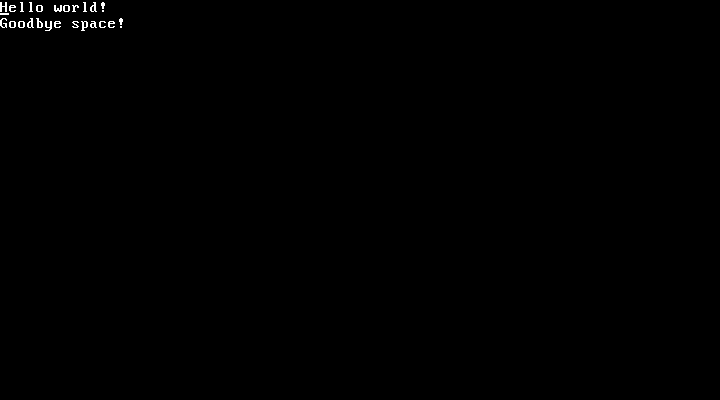